# Week12_Wednesday slides

## Week 12 Wednesday

Wednesday, April 15, 2026

**Announcements**

- A08 (project proposal) due **Friday**: 4/17
- A09 Assigned: Due Monday, May 4, 2026

**Goals**

- Debrief on A05 Lit Review
- In-Class exercise work

## Lit Review Feedback Themes (to help with proposal)

1. If a sentence has no informational content, it should not be in your document.
2. If a statement is *falsifiable* (if it is a claim that could be either true or false), it needs evidentiary support in the form of a citation, a figure, or a table
3. Introspective statements about the assignment, *especially* those that break the "4th wall" are not appropriate for a technical document and should not be used.

> Snake robots are often perceived as frightening, even though they are useful in many household tasks

> These terms were then developed and interchanged until they became an accurate representation of the research questions proposed.

> I chose to study snake robots because I hoped to learn more about legless locomotion. I hoped that it wouldn't be too difficult but also challenging enough to build into a final project.

## Camera Projection

Most of the time, we use a "pinhole camera model" to understand how cameras map real-world light sources to pixel values on an image sensor. For a more in-depth treatment of camera calibration, distortion, and projection, see [this resource](https://docs.opencv.org/4.x/d9/d0c/group__calib3d.html)

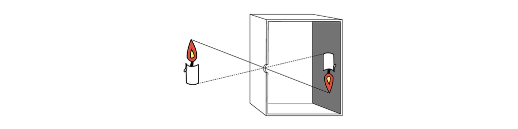

## Camera Projection

The pinhole camera reverses image directions. Camera coordinates are set up to be automatically reflected, so we use a modified model of the pinhole camera to think about projection. The camera's focal length $f$ dictates the mapping between light rays coming into the "pinhole" and where that light impacts the image sensor.

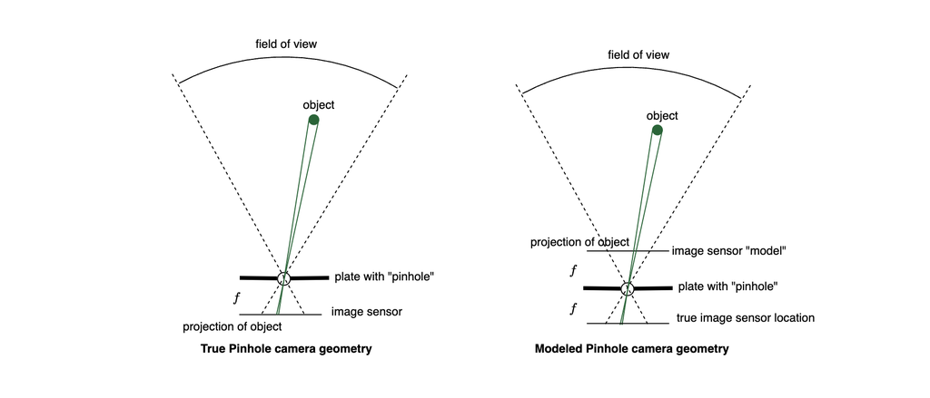

## Camera Projection

[figure not shown]

A camera maps any point: $$^c\vec{p}=\begin{bmatrix}^cX_p & ^cY_p & ^cZ_p\end{bmatrix}^T$$ in the camera-fixed frame $\left\{c\right\}$ to an image coordinate system: $$\begin{bmatrix}u&v\end{bmatrix}^T$$

This can be expressed as the following transformation, where "s" is a scale factor ($s=^cZ_p$): $$s\begin{bmatrix} u \\ v \\ 1 \end{bmatrix} = \underbrace{\begin{bmatrix}f_x & 0 & c_x \\ 0 & f_y & c_y \\ 0 & 0 & 1 \end{bmatrix}}_{\textrm{camera intrinsic matrix} K}\begin{bmatrix}^cX_p \\ ^cY_p \\ ^cZ_p\end{bmatrix}$$

$f_x$ and $f_y$ allow for different effective focal lengths in each direction (nonuniform pixels) and $c_x,c_y$ represent the effective image center. But because this is a homogeneous transformation, the $z$ coordinate loses meaning! In performing this projection, we lose the depth of the object $^cZ_p$!

.

.

.

## What does it mean to "lose" depth information?

It means that we can always "scale" row and column by some arbitrary depth, and get the same thing... and we *cannot* just invert the transformation to recover depth! Writing this as a *homogeneous* coordinate equation gives us what is called the *projective transformation* between 3D homogeneous coordinates in the camera frame to 2D homogeneous "image coordinates": $$ ^cZ_p \begin{bmatrix}^cX^\prime_p \\ ^cY^\prime_p \\1\end{bmatrix} = \underbrace{\begin{bmatrix}1 & 0 & 0 & 0 \\ 0 & 1 & 0 & 0 \\ 0 & 0 & 1 & 0 \\ 0 & 0 & 0 & 0 \end{bmatrix}}_{P} \begin{bmatrix}^cX_p \\ ^cY_p \\ ^cZ_p \\ 1\end{bmatrix}$$

$$ \rightarrow ^cX^\prime _p = \frac{^cX_p}{^cZ_p}$$ $$ \rightarrow ^cY^\prime _p = \frac{^cY_p}{^cZ_p}$$

## This allows us to rewrite the projection equation as follows

$$\begin{bmatrix} \frac{su}{^cZ_p} \\ \frac{sv}{^cZ_p} \\ \frac{s}{^cZ_p} \end{bmatrix} = \begin{bmatrix} u \\ v \\ 1 \end{bmatrix} = K\begin{bmatrix}^cX^\prime_p \\ ^cY^\prime_p \\1\end{bmatrix} = \begin{bmatrix}f_x & 0 & c_x \\ 0 & f_y & c_y \\ 0 & 0 & 1 \end{bmatrix} \begin{bmatrix}^cX^\prime_p \\ ^cY^\prime_p \\1\end{bmatrix} = \begin{bmatrix} f_x \frac{^cX_p}{^cZ_p} + c_x \\ f_y \frac{^cY_p}{^cZ_p} + c_y \end{bmatrix}$$

## What if the point we want to project isn't in the camera-fixed frame $\left\{c\right\}$?

Say our original point is in frame $\left\{A\right\}$. We know that we can write a homogeneous transformation: $$ \begin{bmatrix} ^cX_p \\ ^cY_p \\ ^cZ_p \\ 1 \end{bmatrix} = ^c_AT ^A\vec{p}_h $$

With the transformation matrix defined as: $$ _A^c T = \left[ \begin{array}{ccc|c} & _A^CR & & ^c\vec{r}_{A/c} \\ \hline 0 & 0 & 0 & 1 \end{array}\right]$$

where $^A\vec{r}_{C/A}$ represents, in frame $\left\{c\right\}$, the translation matrix representing the position of the origin of frame $\left\{A\right\}$ relative to frame $\left\{c\right\}$

## What if the point we want to project isn't in the camera-fixed frame $\left\{c\right\}$?

We can combine the projective transformation $P$ with our 3D transformation to write the row and column for point $^A\vec{p}$ as follows:

$$ s\begin{bmatrix} u \\ v \\ 1 \end{bmatrix} = K\cdot \underbrace{P \cdot \underbrace{^c_AT ^A \cdot \vec{p}_h}_{^c\vec{p}_h}}_{^cZ_p \begin{bmatrix}^cX^\prime_p \\ ^cY^\prime_p \\1\end{bmatrix}} $$

As before, $s=^cZ_p$, which means that we can find the row and column occupied by point $p$ by dividing the first two rows of the result of this transformation by the third.

## But given an object's $u$ and $v$, how do I find its world coordinates?

One option is to use a "stereo camera!" If the cameras are identical, and perfectly aligned and separated by a "baseline" distance $B$ in the column-direction,

[figure not shown]

The addition of a second camera allows us to construct a set of equations and unkowns that enable solving for the "depth" of point $p$, from which its 3D pose can be reconstructed. $$\left\{\begin{aligned} ^LX_p &= ^RX_p+B \\ u_L &= f_x \frac{^LX_p}{^LZ_p}+c_x \\ u_R &= f_x \frac{^RX_p}{^RZ_p}+c_x \end{aligned}\right.$$ challenges:

- Expense
- "Correspondence" of point $p$ in left image to same point $p$ in right image.

### But given an object's $u$ and $v$, how do I find its world coordinates?

Another option in *very* specific circumstances is that if we know *something* about the environment or an opject (e.g. sphere diameter?), we can recover depth using this *semantic* information.

[figure not shown]

Knowing $D$ allows us to construct a set of equations and unkowns that enable solving for the "depth" of point $p$. $$\left\{\begin{aligned}\left( ^cX_R - ^cX_L \right) &= D \\ u_L &= f_x \frac{^cX_L}{^cZ_L}+c_x \\ u_R &= f_x \frac{^cX_R}{^cZ_R}+c_x \\ ^cZ_L&=^cZ_R = ^cZ_p \end{aligned}\right.$$ $$\rightarrow ^cZ_{p} = \frac{Df}{u_R-u_L}$$ And with this known, the projection equations can be inverted to recover $^c\vec{p}$ based on camera measurements.

## Webots Note

Note that the focal length $f$ of cameras in Webots is not directly measurable. You can computer $f$ using:

$$ f = \frac{width}{\tan(fov)}$$

you can get the camera's Field of View (fov) and pixel-width using:

```
fov = camera.getFov()
width = camera.getWidth()
```

and you can assume that the image center is at the half-width and half-height of its images.

.

.

.

## Class Exercise 1: Image Processing

In the Week12_InClass world, the Romi is equipped with a camera. Inside the controller file, you are already presented with the methodology to read camera frames in Webots.

1. Allow the Romi to explore using an explore FSM unless it sees a ball.
2. Once a ball is in frame, use a feedback controller to "aim" (angle in yaw) the Romi so that the center of the ball is in the center of the image.

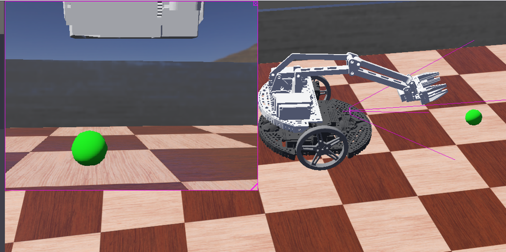

## Class Exercise 2: Camera Projection

In the Week12_InClass world, the Romi is equipped with a camera. Inside the controller file, you are already presented with the methodology to read camera frames in Webots.

1. Allow the Romi to explore using an explore FSM unless it sees a ball.
2. Once a ball is in frame, use a feedback controller to "aim" (angle in yaw) the Romi so that the center of the ball is in the center of the image.
3. Measure the **distance from the Romi (not the camera!) to the ball!** Compare this with "ground truth" distance measurements from a supervisor, or from a GPS measurement of Romi position and a known ball location.

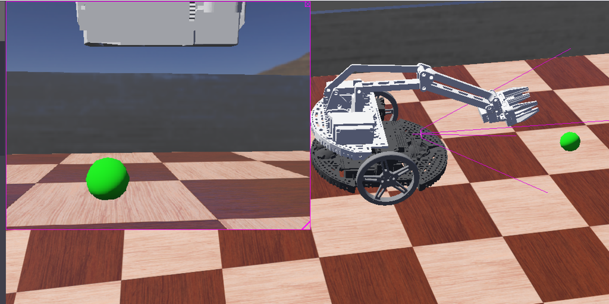